# Week 4 pitch to the Final Project

2024-01-08

## Introduction

For this project, I used data from my co-authored PloSone journal article, “Macroscale abundance patterns of hydromedusae in the temperate Southwestern Atlantic (27°–56° S).” Based on a large dataset gathered over about 40 years, the article discusses the distribution of jellyfish throughout the Atlantic Ocean. The article can be found at https://doi.org/10.1371/journal.pone.0217628, and the data are at the SEANOE website: https://www.seanoe.org/data/00501/61229/. The project includes the interactive plots required for the second and third week’s assignments, as well as the shiny apps for the fourth week of the Developing Data Products course from Johns Hopkins University

## Study Area

Sampling location from the article: Macroscale abundance patterns of hydromedusae in the temperate Southwestern Atlantic (27°–56° S).

```r
library(tidyverse)
library(maps)
library(mapdata)
world_coordinates <- map_data("world")

rect <- data.frame(lon = c(-69.20, -45.01, -45.01, -69.20),
                   lat = c(-55.10, -55.10, -26.73, -26.73))

world_plot <- ggplot() +
  geom_map(data = world_coordinates, map = world_coordinates,
           aes(long, lat, map_id = region), color = 'white', fill = 'bisque3') +
  coord_map("ortho", orientation = c(-50, -50, 0)) +
  scale_y_continuous(breaks = seq(-180, 180, 20)) +
  geom_polygon(data = rect, aes(lon, lat, group = 1),
               fill = "dodgerblue3", color = "grey", alpha = .3) +
  theme(title = element_text(size = 9, color = "grey40"),
        axis.title = element_text(color = 'transparent'),
        axis.text = element_text(color = 'transparent'),
        axis.ticks = element_line(color = 'transparent'),
        panel.grid.major = element_line(linewidth = .9),
        plot.background = element_rect(color = 'transparent', fill = 'transparent'))
```

## Study Area plot

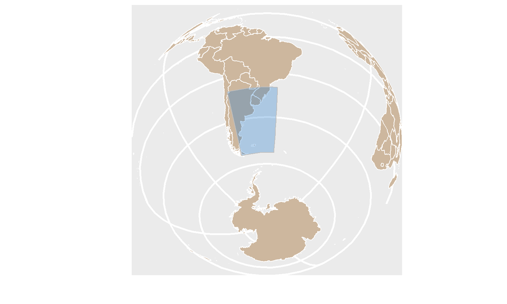

```r
world_plot
```